# Sales Analysis

Import Libraries

```python
import pandas as pd
import os
import seaborn as sns
import matplotlib
import matplotlib.pyplot as plt
plt.style.use('ggplot')
from matplotlib.pyplot import figure

%matplotlib inline
matplotlib.rcParams['figure.figsize']=(14,6)
```

Merge the 12 months of sales data

```python
df=pd.read_csv(r"C:\Users\NOCAY\Desktop\Sales_Data\Sales_April_2019.csv")
```

```python
files = [file for file in os.listdir(r"C:\Users\NOCAY\Desktop\DATA SCIENCE\real time solv\solving real world science tasks\Pandas-Data-Science-Tasks-master\SalesAnalysis\Sales_Data")]
for file in files:
    print(file)
file
```

```
Sales_April_2019.csv
Sales_August_2019.csv
Sales_December_2019.csv
Sales_February_2019.csv
Sales_January_2019.csv
Sales_July_2019.csv
Sales_June_2019.csv
Sales_March_2019.csv
Sales_May_2019.csv
Sales_November_2019.csv
Sales_October_2019.csv
Sales_September_2019.csv
```

```
'Sales_September_2019.csv'
```

```python
A=pd.read_csv(r"C:\Users\NOCAY\Desktop\DATA SCIENCE\real time solv\solving real world science tasks\Pandas-Data-Science-Tasks-master\SalesAnalysis\Sales_Data\Sales_January_2019.csv")
B=pd.read_csv(r"C:\Users\NOCAY\Desktop\DATA SCIENCE\real time solv\solving real world science tasks\Pandas-Data-Science-Tasks-master\SalesAnalysis\Sales_Data\Sales_February_2019.csv")
C=pd.read_csv(r"C:\Users\NOCAY\Desktop\DATA SCIENCE\real time solv\solving real world science tasks\Pandas-Data-Science-Tasks-master\SalesAnalysis\Sales_Data\Sales_March_2019.csv")
D=pd.read_csv(r"C:\Users\NOCAY\Desktop\DATA SCIENCE\real time solv\solving real world science tasks\Pandas-Data-Science-Tasks-master\SalesAnalysis\Sales_Data\Sales_April_2019.csv")
E=pd.read_csv(r"C:\Users\NOCAY\Desktop\DATA SCIENCE\real time solv\solving real world science tasks\Pandas-Data-Science-Tasks-master\SalesAnalysis\Sales_Data\Sales_May_2019.csv")
F=pd.read_csv(r"C:\Users\NOCAY\Desktop\DATA SCIENCE\real time solv\solving real world science tasks\Pandas-Data-Science-Tasks-master\SalesAnalysis\Sales_Data\Sales_June_2019.csv")
G=pd.read_csv(r"C:\Users\NOCAY\Desktop\DATA SCIENCE\real time solv\solving real world science tasks\Pandas-Data-Science-Tasks-master\SalesAnalysis\Sales_Data\Sales_July_2019.csv")
H=pd.read_csv(r"C:\Users\NOCAY\Desktop\DATA SCIENCE\real time solv\solving real world science tasks\Pandas-Data-Science-Tasks-master\SalesAnalysis\Sales_Data\Sales_August_2019.csv")
I=pd.read_csv(r"C:\Users\NOCAY\Desktop\DATA SCIENCE\real time solv\solving real world science tasks\Pandas-Data-Science-Tasks-master\SalesAnalysis\Sales_Data\Sales_September_2019.csv")
J=pd.read_csv(r"C:\Users\NOCAY\Desktop\DATA SCIENCE\real time solv\solving real world science tasks\Pandas-Data-Science-Tasks-master\SalesAnalysis\Sales_Data\Sales_October_2019.csv")
K=pd.read_csv(r"C:\Users\NOCAY\Desktop\DATA SCIENCE\real time solv\solving real world science tasks\Pandas-Data-Science-Tasks-master\SalesAnalysis\Sales_Data\Sales_November_2019.csv")
L=pd.read_csv(r"C:\Users\NOCAY\Desktop\DATA SCIENCE\real time solv\solving real world science tasks\Pandas-Data-Science-Tasks-master\SalesAnalysis\Sales_Data\Sales_December_2019.csv")
```

```python
allData = pd.concat([A,B,C,D,E,F,G,H,I,J,K,L], axis=0)
```

```python
allData
```

|  | Order ID | Product | Quantity Ordered | Price Each | Order Date | Purchase Address |
| --- | --- | --- | --- | --- | --- | --- |
| 0 | 141234 | iPhone | 1 | 700 | 01/22/19 21:25 | 944 Walnut St, Boston, MA 02215 |
| 1 | 141235 | Lightning Charging Cable | 1 | 14.95 | 01/28/19 14:15 | 185 Maple St, Portland, OR 97035 |
| 2 | 141236 | Wired Headphones | 2 | 11.99 | 01/17/19 13:33 | 538 Adams St, San Francisco, CA 94016 |
| 3 | 141237 | 27in FHD Monitor | 1 | 149.99 | 01/05/19 20:33 | 738 10th St, Los Angeles, CA 90001 |
| 4 | 141238 | Wired Headphones | 1 | 11.99 | 01/25/19 11:59 | 387 10th St, Austin, TX 73301 |
| ... | ... | ... | ... | ... | ... | ... |
| 25112 | 319666 | Lightning Charging Cable | 1 | 14.95 | 12/11/19 20:58 | 14 Madison St, San Francisco, CA 94016 |
| 25113 | 319667 | AA Batteries (4-pack) | 2 | 3.84 | 12/01/19 12:01 | 549 Willow St, Los Angeles, CA 90001 |
| 25114 | 319668 | Vareebadd Phone | 1 | 400 | 12/09/19 06:43 | 273 Wilson St, Seattle, WA 98101 |
| 25115 | 319669 | Wired Headphones | 1 | 11.99 | 12/03/19 10:39 | 778 River St, Dallas, TX 75001 |
| 25116 | 319670 | Bose SoundSport Headphones | 1 | 99.99 | 12/21/19 21:45 | 747 Chestnut St, Los Angeles, CA 90001 |

186850 rows × 6 columns

```python
allData.to_csv('allData.csv', index=False)
```

TASK 1: BEST MONTH FOR SALES AND HOW MUCH WAS EARNED

```python
allData.head()
```

|  | Order ID | Product | Quantity Ordered | Price Each | Order Date | Purchase Address |
| --- | --- | --- | --- | --- | --- | --- |
| 0 | 141234 | iPhone | 1 | 700 | 01/22/19 21:25 | 944 Walnut St, Boston, MA 02215 |
| 1 | 141235 | Lightning Charging Cable | 1 | 14.95 | 01/28/19 14:15 | 185 Maple St, Portland, OR 97035 |
| 2 | 141236 | Wired Headphones | 2 | 11.99 | 01/17/19 13:33 | 538 Adams St, San Francisco, CA 94016 |
| 3 | 141237 | 27in FHD Monitor | 1 | 149.99 | 01/05/19 20:33 | 738 10th St, Los Angeles, CA 90001 |
| 4 | 141238 | Wired Headphones | 1 | 11.99 | 01/25/19 11:59 | 387 10th St, Austin, TX 73301 |

Add Month Column

```python
allData['Month'] = allData['Order Date'].str[0:2]
allData.head()
```

|  | Order ID | Product | Quantity Ordered | Price Each | Order Date | Purchase Address | Month |
| --- | --- | --- | --- | --- | --- | --- | --- |
| 0 | 141234 | iPhone | 1 | 700 | 01/22/19 21:25 | 944 Walnut St, Boston, MA 02215 | 01 |
| 1 | 141235 | Lightning Charging Cable | 1 | 14.95 | 01/28/19 14:15 | 185 Maple St, Portland, OR 97035 | 01 |
| 2 | 141236 | Wired Headphones | 2 | 11.99 | 01/17/19 13:33 | 538 Adams St, San Francisco, CA 94016 | 01 |
| 3 | 141237 | 27in FHD Monitor | 1 | 149.99 | 01/05/19 20:33 | 738 10th St, Los Angeles, CA 90001 | 01 |
| 4 | 141238 | Wired Headphones | 1 | 11.99 | 01/25/19 11:59 | 387 10th St, Austin, TX 73301 | 01 |

```python
allData['Month'].unique()
```

```
array(['01', nan, 'Or', '02', '03', '04', '05', '06', '07', '08', '09',
       '10', '11', '12'], dtype=object)
```

We need to drop all data with value Or

```python
allData = allData[allData['Order Date'].str[0:2]!='Or']
```

Check the datasets

```python
allData.shape
```

```
(186495, 7)
```

```python
allData.info()
```

```
<class 'pandas.core.frame.DataFrame'>
Int64Index: 186495 entries, 0 to 25116
Data columns (total 7 columns):
 #   Column            Non-Null Count   Dtype
---  ------            --------------   -----
 0   Order ID          185950 non-null  object
 1   Product           185950 non-null  object
 2   Quantity Ordered  185950 non-null  object
 3   Price Each        185950 non-null  object
 4   Order Date        185950 non-null  object
 5   Purchase Address  185950 non-null  object
 6   Month             185950 non-null  object
dtypes: object(7)
memory usage: 11.4+ MB
```

```python
allData.describe()
```

|  | Order ID | Product | Quantity Ordered | Price Each | Order Date | Purchase Address | Month |
| --- | --- | --- | --- | --- | --- | --- | --- |
| count | 185950 | 185950 | 185950 | 185950 | 185950 | 185950 | 185950 |
| unique | 178437 | 19 | 9 | 23 | 142395 | 140787 | 12 |
| top | 160873 | USB-C Charging Cable | 1 | 11.95 | 12/15/19 20:16 | 193 Forest St, San Francisco, CA 94016 | 12 |
| freq | 5 | 21903 | 168552 | 21903 | 8 | 9 | 24984 |

```python
allData.isnull().sum()
```

```
Order ID            545
Product             545
Quantity Ordered    545
Price Each          545
Order Date          545
Purchase Address    545
Month               545
dtype: int64
```

Now we need to clean up our data by dropping the null rows and converting Price and Quantity Ordered columns to integer

```python
nullData = allData.isnull()
nullData.head()
allData = allData.dropna(how='all')
allData
```

|  | Order ID | Product | Quantity Ordered | Price Each | Order Date | Purchase Address | Month |
| --- | --- | --- | --- | --- | --- | --- | --- |
| 0 | 141234 | iPhone | 1 | 700 | 01/22/19 21:25 | 944 Walnut St, Boston, MA 02215 | 01 |
| 1 | 141235 | Lightning Charging Cable | 1 | 14.95 | 01/28/19 14:15 | 185 Maple St, Portland, OR 97035 | 01 |
| 2 | 141236 | Wired Headphones | 2 | 11.99 | 01/17/19 13:33 | 538 Adams St, San Francisco, CA 94016 | 01 |
| 3 | 141237 | 27in FHD Monitor | 1 | 149.99 | 01/05/19 20:33 | 738 10th St, Los Angeles, CA 90001 | 01 |
| 4 | 141238 | Wired Headphones | 1 | 11.99 | 01/25/19 11:59 | 387 10th St, Austin, TX 73301 | 01 |
| ... | ... | ... | ... | ... | ... | ... | ... |
| 25112 | 319666 | Lightning Charging Cable | 1 | 14.95 | 12/11/19 20:58 | 14 Madison St, San Francisco, CA 94016 | 12 |
| 25113 | 319667 | AA Batteries (4-pack) | 2 | 3.84 | 12/01/19 12:01 | 549 Willow St, Los Angeles, CA 90001 | 12 |
| 25114 | 319668 | Vareebadd Phone | 1 | 400 | 12/09/19 06:43 | 273 Wilson St, Seattle, WA 98101 | 12 |
| 25115 | 319669 | Wired Headphones | 1 | 11.99 | 12/03/19 10:39 | 778 River St, Dallas, TX 75001 | 12 |
| 25116 | 319670 | Bose SoundSport Headphones | 1 | 99.99 | 12/21/19 21:45 | 747 Chestnut St, Los Angeles, CA 90001 | 12 |

185950 rows × 7 columns

```python
allData.isnull().sum()
```

```
Order ID            0
Product             0
Quantity Ordered    0
Price Each          0
Order Date          0
Purchase Address    0
Month               0
dtype: int64
```

Now lets Create another Column called Sales

```python
allData['Sales'] = allData['Quantity Ordered'] * allData['Price Each']
```

[output not shown]

[output cut: 18 more lines]

[output not shown]

We need to convert the columns Quantity Ordered and Price Each to integer

```python
allData['Quantity Ordered'] = allData['Quantity Ordered'].astype('int64')
allData['Quantity Ordered'].dtypes
```

```
dtype('int64')
```

```python
allData['Quantity Ordered'].unique()
```

```
array([1, 2, 3, 5, 4, 7, 6, 9, 8], dtype=int64)
```

```python
allData['Quantity Ordered'].replace({'Quantity Ordered':0}, inplace = True)
```

```python
allData['Quantity Ordered'].unique()
```

```
array([1, 2, 3, 5, 4, 7, 6, 9, 8], dtype=int64)
```

```python
allData['Price Each'].unique()
```

```
array(['700', '14.95', '11.99', '149.99', '2.99', '389.99', '11.95',
       '99.99', '150', '1700', '300', '400', '3.84', '600', '109.99',
       '379.99', '999.99', '600.0', '700.0', '150.0', '300.0', '1700.0',
       '400.0'], dtype=object)
```

```python
allData['Price Each'].replace({'Price Each':0}, inplace = True)
allData['Price Each'].unique()
```

```
array(['700', '14.95', '11.99', '149.99', '2.99', '389.99', '11.95',
       '99.99', '150', '1700', '300', '400', '3.84', '600', '109.99',
       '379.99', '999.99', '600.0', '700.0', '150.0', '300.0', '1700.0',
       '400.0'], dtype=object)
```

Now lets create Change the columns to integer and then create column Sales

```python
allData['Quantity Ordered'] = allData['Quantity Ordered'].astype('int64')
```

```python
allData['Price Each'] = allData['Price Each'].astype('int64')
```

[output not shown]

```python
allData['Quantity Ordered'].dtypes
```

```
dtype('int64')
```

```python
allData['Price Each'] = pd.to_numeric(allData['Price Each'])
allData['Price Each']
```

```
0        700.00
1         14.95
2         11.99
3        149.99
4         11.99
          ...
25112     14.95
25113      3.84
25114    400.00
25115     11.99
25116     99.99
Name: Price Each, Length: 185950, dtype: float64
```

```python
allData['Sales'] = allData['Quantity Ordered'] * allData['Price Each']
allData['Sales']
```

```
0        700.00
1         14.95
2         23.98
3        149.99
4         11.99
          ...
25112     14.95
25113      7.68
25114    400.00
25115     11.99
25116     99.99
Name: Sales, Length: 185950, dtype: float64
```

```python
allData.head()
```

|  | Order ID | Product | Quantity Ordered | Price Each | Order Date | Purchase Address | Month | Sales |
| --- | --- | --- | --- | --- | --- | --- | --- | --- |
| 0 | 141234 | iPhone | 1 | 700.00 | 01/22/19 21:25 | 944 Walnut St, Boston, MA 02215 | 01 | 700.00 |
| 1 | 141235 | Lightning Charging Cable | 1 | 14.95 | 01/28/19 14:15 | 185 Maple St, Portland, OR 97035 | 01 | 14.95 |
| 2 | 141236 | Wired Headphones | 2 | 11.99 | 01/17/19 13:33 | 538 Adams St, San Francisco, CA 94016 | 01 | 23.98 |
| 3 | 141237 | 27in FHD Monitor | 1 | 149.99 | 01/05/19 20:33 | 738 10th St, Los Angeles, CA 90001 | 01 | 149.99 |
| 4 | 141238 | Wired Headphones | 1 | 11.99 | 01/25/19 11:59 | 387 10th St, Austin, TX 73301 | 01 | 11.99 |

```python
results = allData.groupby('Month').sum()
results
```

| Month | Quantity Ordered | Price Each | Sales |
| --- | --- | --- | --- |
| 01 | 10903 | 1811768.38 | 1822256.73 |
| 02 | 13449 | 2188884.72 | 2202022.42 |
| 03 | 17005 | 2791207.83 | 2807100.38 |
| 04 | 20558 | 3367671.02 | 3390670.24 |
| 05 | 18667 | 3135125.13 | 3152606.75 |
| 06 | 15253 | 2562025.61 | 2577802.26 |
| 07 | 16072 | 2632539.56 | 2647775.76 |
| 08 | 13448 | 2230345.42 | 2244467.88 |
| 09 | 13109 | 2084992.09 | 2097560.13 |
| 10 | 22703 | 3715554.83 | 3736726.88 |
| 11 | 19798 | 3180600.68 | 3199603.20 |
| 12 | 28114 | 4588415.41 | 4613443.34 |

Now December has the highest Sales with 4,613,443.34 as total sales

```python
import matplotlib.pyplot as plt
```

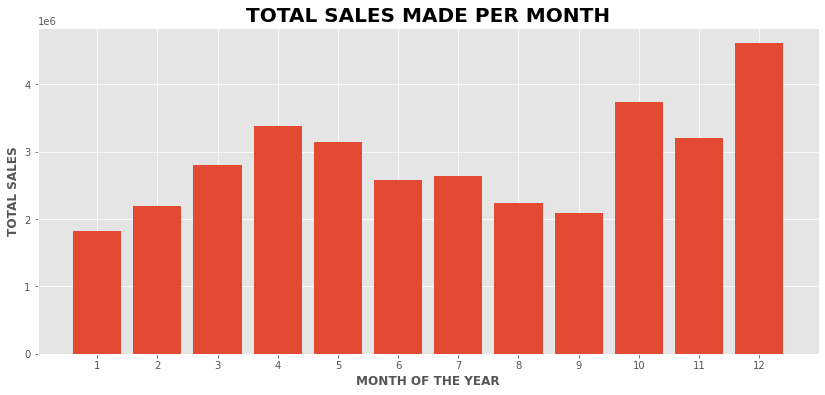

```python
months = range(1,13)
plt.bar(months, results['Sales'])
plt.title('TOTAL SALES MADE PER MONTH',fontweight='bold', fontsize=20)
plt.xlabel('MONTH OF THE YEAR',fontweight='bold')
plt.xticks(months)
plt.ylabel('TOTAL SALES',fontweight='bold')
plt.show()
```

WHAT PRODUCT HAS THE HIGHEST NUMBER OF SALES

```python
allData.head()
```

|  | Order ID | Product | Quantity Ordered | Price Each | Order Date | Purchase Address | Month | Sales |
| --- | --- | --- | --- | --- | --- | --- | --- | --- |
| 0 | 141234 | iPhone | 1 | 700.00 | 01/22/19 21:25 | 944 Walnut St, Boston, MA 02215 | 01 | 700.00 |
| 1 | 141235 | Lightning Charging Cable | 1 | 14.95 | 01/28/19 14:15 | 185 Maple St, Portland, OR 97035 | 01 | 14.95 |
| 2 | 141236 | Wired Headphones | 2 | 11.99 | 01/17/19 13:33 | 538 Adams St, San Francisco, CA 94016 | 01 | 23.98 |
| 3 | 141237 | 27in FHD Monitor | 1 | 149.99 | 01/05/19 20:33 | 738 10th St, Los Angeles, CA 90001 | 01 | 149.99 |
| 4 | 141238 | Wired Headphones | 1 | 11.99 | 01/25/19 11:59 | 387 10th St, Austin, TX 73301 | 01 | 11.99 |

```python
productSales = allData.groupby('Product').sum()
productSales
```

| Product | Quantity Ordered | Price Each | Sales |
| --- | --- | --- | --- |
| 20in Monitor | 4129 | 451068.99 | 454148.71 |
| 27in 4K Gaming Monitor | 6244 | 2429637.70 | 2435097.56 |
| 27in FHD Monitor | 7550 | 1125974.93 | 1132424.50 |
| 34in Ultrawide Monitor | 6199 | 2348718.19 | 2355558.01 |
| AA Batteries (4-pack) | 27635 | 79015.68 | 106118.40 |
| AAA Batteries (4-pack) | 31017 | 61716.59 | 92740.83 |
| Apple Airpods Headphones | 15661 | 2332350.00 | 2349150.00 |
| Bose SoundSport Headphones | 13457 | 1332366.75 | 1345565.43 |
| Flatscreen TV | 4819 | 1440000.00 | 1445700.00 |
| Google Phone | 5532 | 3315000.00 | 3319200.00 |
| LG Dryer | 646 | 387600.00 | 387600.00 |
| LG Washing Machine | 666 | 399600.00 | 399600.00 |
| Lightning Charging Cable | 23217 | 323787.10 | 347094.15 |
| Macbook Pro Laptop | 4728 | 8030800.00 | 8037600.00 |
| ThinkPad Laptop | 4130 | 4127958.72 | 4129958.70 |
| USB-C Charging Cable | 23975 | 261740.85 | 286501.25 |
| Vareebadd Phone | 2068 | 826000.00 | 827200.00 |
| Wired Headphones | 20557 | 226395.18 | 246478.43 |
| iPhone | 6849 | 4789400.00 | 4794300.00 |

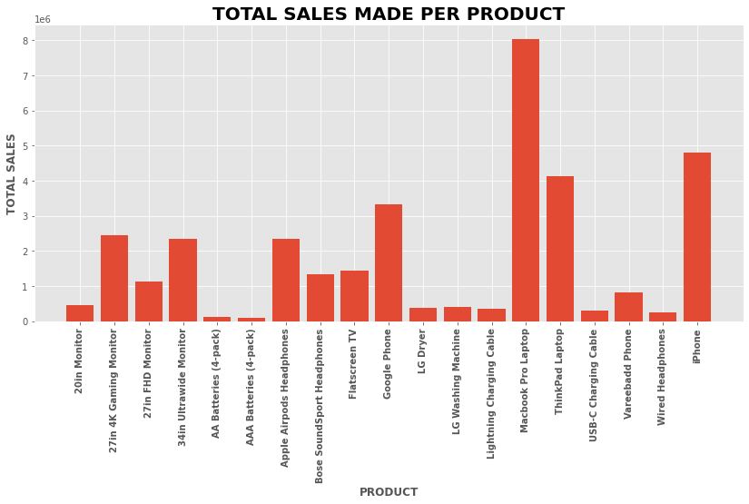

```python
products = [product for product, df in allData.groupby('Product')]

plt.bar(products, productSales['Sales'])
plt.title('TOTAL SALES MADE PER PRODUCT',fontsize=20, fontweight='bold')
plt.xlabel('PRODUCT',fontweight='bold')
plt.xticks(products, rotation='vertical', size=10, fontweight='bold')
plt.ylabel('TOTAL SALES',fontweight='bold')
plt.show()
```

CITY WITH THE HIGHEST SALES

```python
allData.head()
```

|  | Order ID | Product | Quantity Ordered | Price Each | Order Date | Purchase Address | Month | Sales |
| --- | --- | --- | --- | --- | --- | --- | --- | --- |
| 0 | 141234 | iPhone | 1 | 700.00 | 01/22/19 21:25 | 944 Walnut St, Boston, MA 02215 | 01 | 700.00 |
| 1 | 141235 | Lightning Charging Cable | 1 | 14.95 | 01/28/19 14:15 | 185 Maple St, Portland, OR 97035 | 01 | 14.95 |
| 2 | 141236 | Wired Headphones | 2 | 11.99 | 01/17/19 13:33 | 538 Adams St, San Francisco, CA 94016 | 01 | 23.98 |
| 3 | 141237 | 27in FHD Monitor | 1 | 149.99 | 01/05/19 20:33 | 738 10th St, Los Angeles, CA 90001 | 01 | 149.99 |
| 4 | 141238 | Wired Headphones | 1 | 11.99 | 01/25/19 11:59 | 387 10th St, Austin, TX 73301 | 01 | 11.99 |

```python
allData['City'] = allData['Purchase Address'].apply(lambda x: x.split(',')[1])
allData.head()
```

|  | Order ID | Product | Quantity Ordered | Price Each | Order Date | Purchase Address | Month | Sales | City |
| --- | --- | --- | --- | --- | --- | --- | --- | --- | --- |
| 0 | 141234 | iPhone | 1 | 700.00 | 01/22/19 21:25 | 944 Walnut St, Boston, MA 02215 | 01 | 700.00 | Boston |
| 1 | 141235 | Lightning Charging Cable | 1 | 14.95 | 01/28/19 14:15 | 185 Maple St, Portland, OR 97035 | 01 | 14.95 | Portland |
| 2 | 141236 | Wired Headphones | 2 | 11.99 | 01/17/19 13:33 | 538 Adams St, San Francisco, CA 94016 | 01 | 23.98 | San Francisco |
| 3 | 141237 | 27in FHD Monitor | 1 | 149.99 | 01/05/19 20:33 | 738 10th St, Los Angeles, CA 90001 | 01 | 149.99 | Los Angeles |
| 4 | 141238 | Wired Headphones | 1 | 11.99 | 01/25/19 11:59 | 387 10th St, Austin, TX 73301 | 01 | 11.99 | Austin |

You could also define a function to extract our City from Column Purchase Address

```python
def get_city(address):
    return address.split(',')[1]
allData['City'] = allData['Purchase Address'].apply(lambda x: get_city(x))
allData.head()
```

|  | Order ID | Product | Quantity Ordered | Price Each | Order Date | Purchase Address | Month | Sales | City |
| --- | --- | --- | --- | --- | --- | --- | --- | --- | --- |
| 0 | 141234 | iPhone | 1 | 700.00 | 01/22/19 21:25 | 944 Walnut St, Boston, MA 02215 | 01 | 700.00 | Boston |
| 1 | 141235 | Lightning Charging Cable | 1 | 14.95 | 01/28/19 14:15 | 185 Maple St, Portland, OR 97035 | 01 | 14.95 | Portland |
| 2 | 141236 | Wired Headphones | 2 | 11.99 | 01/17/19 13:33 | 538 Adams St, San Francisco, CA 94016 | 01 | 23.98 | San Francisco |
| 3 | 141237 | 27in FHD Monitor | 1 | 149.99 | 01/05/19 20:33 | 738 10th St, Los Angeles, CA 90001 | 01 | 149.99 | Los Angeles |
| 4 | 141238 | Wired Headphones | 1 | 11.99 | 01/25/19 11:59 | 387 10th St, Austin, TX 73301 | 01 | 11.99 | Austin |

```python
allData['City'].unique()
```

```
array([' Boston', ' Portland', ' San Francisco', ' Los Angeles',
       ' Austin', ' Atlanta', ' Seattle', ' New York City', ' Dallas'],
      dtype=object)
```

```python
highestCity = allData.groupby('City').sum()
highestCity
```

| City | Quantity Ordered | Price Each | Sales |
| --- | --- | --- | --- |
| Atlanta | 16602 | 2779908.20 | 2795498.58 |
| Austin | 11153 | 1809873.61 | 1819581.75 |
| Boston | 22528 | 3637409.77 | 3661642.01 |
| Dallas | 16730 | 2752627.82 | 2767975.40 |
| Los Angeles | 33289 | 5421435.23 | 5452570.80 |
| New York City | 27932 | 4635370.83 | 4664317.43 |
| Portland | 14053 | 2307747.47 | 2320490.61 |
| San Francisco | 50239 | 8211461.74 | 8262203.91 |
| Seattle | 16553 | 2733296.01 | 2747755.48 |

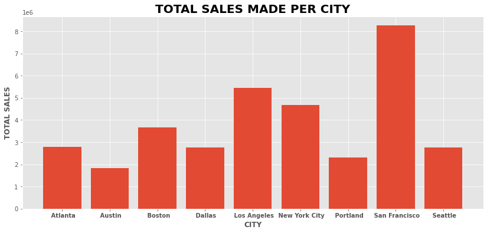

```python
cities = [city for city, df in allData.groupby('City')]

plt.bar(cities, highestCity['Sales'])
plt.title('TOTAL SALES MADE PER CITY', fontweight=
        'bold', fontsize=20)
plt.xlabel('CITY',fontweight='bold')
plt.xticks(cities, fontweight='bold')
plt.ylabel('TOTAL SALES',fontweight='bold')
plt.show()
```

WHEN SHOULD WE DISPLAY ADVERTS TO INCREASE THE LIKELIHOOD OF CUSTOMERS BUYING PRODUCTS

```python
allData.head()
```

[output not shown]

```python
allData['Order Date'] = pd.to_datetime(allData['Order Date'])
```

```python
allData.head()
```

|  | Order ID | Product | Quantity Ordered | Price Each | Order Date | Purchase Address | Month | Sales | City |
| --- | --- | --- | --- | --- | --- | --- | --- | --- | --- |
| 0 | 141234 | iPhone | 1 | 700.00 | 2019-01-22 21:25:00 | 944 Walnut St, Boston, MA 02215 | 01 | 700.00 | Boston |
| 1 | 141235 | Lightning Charging Cable | 1 | 14.95 | 2019-01-28 14:15:00 | 185 Maple St, Portland, OR 97035 | 01 | 14.95 | Portland |
| 2 | 141236 | Wired Headphones | 2 | 11.99 | 2019-01-17 13:33:00 | 538 Adams St, San Francisco, CA 94016 | 01 | 23.98 | San Francisco |
| 3 | 141237 | 27in FHD Monitor | 1 | 149.99 | 2019-01-05 20:33:00 | 738 10th St, Los Angeles, CA 90001 | 01 | 149.99 | Los Angeles |
| 4 | 141238 | Wired Headphones | 1 | 11.99 | 2019-01-25 11:59:00 | 387 10th St, Austin, TX 73301 | 01 | 11.99 | Austin |

```python
allData['hour'] = allData['Order Date'].dt.hour
allData['Minute'] = allData['Order Date'].dt.minute
```

```python
allData.head()
```

|  | Order ID | Product | Quantity Ordered | Price Each | Order Date | Purchase Address | Month | Sales | City | hour | Minuite | Minute |
| --- | --- | --- | --- | --- | --- | --- | --- | --- | --- | --- | --- | --- |
| 0 | 141234 | iPhone | 1 | 700.00 | 2019-01-22 21:25:00 | 944 Walnut St, Boston, MA 02215 | 01 | 700.00 | Boston | 21 | 25 | 25 |
| 1 | 141235 | Lightning Charging Cable | 1 | 14.95 | 2019-01-28 14:15:00 | 185 Maple St, Portland, OR 97035 | 01 | 14.95 | Portland | 14 | 15 | 15 |
| 2 | 141236 | Wired Headphones | 2 | 11.99 | 2019-01-17 13:33:00 | 538 Adams St, San Francisco, CA 94016 | 01 | 23.98 | San Francisco | 13 | 33 | 33 |
| 3 | 141237 | 27in FHD Monitor | 1 | 149.99 | 2019-01-05 20:33:00 | 738 10th St, Los Angeles, CA 90001 | 01 | 149.99 | Los Angeles | 20 | 33 | 33 |
| 4 | 141238 | Wired Headphones | 1 | 11.99 | 2019-01-25 11:59:00 | 387 10th St, Austin, TX 73301 | 01 | 11.99 | Austin | 11 | 59 | 59 |

```python
allData = allData.drop(columns='Minuite')
```

```python
allData.head()
```

|  | Order ID | Product | Quantity Ordered | Price Each | Order Date | Purchase Address | Month | Sales | City | hour | Minute |
| --- | --- | --- | --- | --- | --- | --- | --- | --- | --- | --- | --- |
| 0 | 141234 | iPhone | 1 | 700.00 | 2019-01-22 21:25:00 | 944 Walnut St, Boston, MA 02215 | 01 | 700.00 | Boston | 21 | 25 |
| 1 | 141235 | Lightning Charging Cable | 1 | 14.95 | 2019-01-28 14:15:00 | 185 Maple St, Portland, OR 97035 | 01 | 14.95 | Portland | 14 | 15 |
| 2 | 141236 | Wired Headphones | 2 | 11.99 | 2019-01-17 13:33:00 | 538 Adams St, San Francisco, CA 94016 | 01 | 23.98 | San Francisco | 13 | 33 |
| 3 | 141237 | 27in FHD Monitor | 1 | 149.99 | 2019-01-05 20:33:00 | 738 10th St, Los Angeles, CA 90001 | 01 | 149.99 | Los Angeles | 20 | 33 |
| 4 | 141238 | Wired Headphones | 1 | 11.99 | 2019-01-25 11:59:00 | 387 10th St, Austin, TX 73301 | 01 | 11.99 | Austin | 11 | 59 |

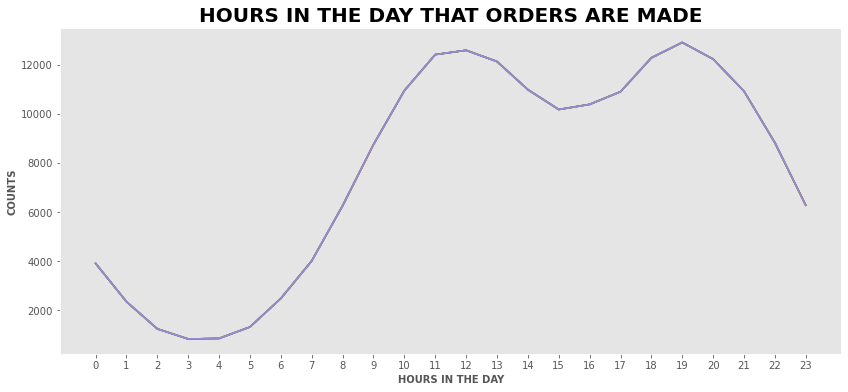

```python
hours = [hr for hr, df in allData.groupby('hour')]

plt.plot(hours, allData.groupby(['hour']).count())
plt.title('HOURS IN THE DAY THAT ORDERS ARE MADE', fontweight='bold', fontsize=20)
plt.xlabel('HOURS IN THE DAY', fontweight='bold', fontsize=10)
plt.ylabel('COUNTS', fontweight='bold', fontsize=10)
plt.xticks(hours)
plt.grid()
plt.show()
```

RECOMMENDATION: ADVERTS SHOULD BE PLACED BETWEEN 11AM AND 7PM

PRODUCTS THAT ARE MOST COMMONLY SOLD TOGETHER

```python
allData.head()
```

|  | Order ID | Product | Quantity Ordered | Price Each | Order Date | Purchase Address | Month | Sales | City | hour | Minute |
| --- | --- | --- | --- | --- | --- | --- | --- | --- | --- | --- | --- |
| 0 | 141234 | iPhone | 1 | 700.00 | 2019-01-22 21:25:00 | 944 Walnut St, Boston, MA 02215 | 01 | 700.00 | Boston | 21 | 25 |
| 1 | 141235 | Lightning Charging Cable | 1 | 14.95 | 2019-01-28 14:15:00 | 185 Maple St, Portland, OR 97035 | 01 | 14.95 | Portland | 14 | 15 |
| 2 | 141236 | Wired Headphones | 2 | 11.99 | 2019-01-17 13:33:00 | 538 Adams St, San Francisco, CA 94016 | 01 | 23.98 | San Francisco | 13 | 33 |
| 3 | 141237 | 27in FHD Monitor | 1 | 149.99 | 2019-01-05 20:33:00 | 738 10th St, Los Angeles, CA 90001 | 01 | 149.99 | Los Angeles | 20 | 33 |
| 4 | 141238 | Wired Headphones | 1 | 11.99 | 2019-01-25 11:59:00 | 387 10th St, Austin, TX 73301 | 01 | 11.99 | Austin | 11 | 59 |

```python
df1 = allData[allData['Order ID'].duplicated(keep=False)]
df1
```

|  | Order ID | Product | Quantity Ordered | Price Each | Order Date | Purchase Address | Month | Sales | City | hour | Minute |
| --- | --- | --- | --- | --- | --- | --- | --- | --- | --- | --- | --- |
| 41 | 141275 | USB-C Charging Cable | 1 | 11.95 | 2019-01-07 16:06:00 | 610 Walnut St, Austin, TX 73301 | 01 | 11.95 | Austin | 16 | 6 |
| 42 | 141275 | Wired Headphones | 1 | 11.99 | 2019-01-07 16:06:00 | 610 Walnut St, Austin, TX 73301 | 01 | 11.99 | Austin | 16 | 6 |
| 57 | 141290 | Apple Airpods Headphones | 1 | 150.00 | 2019-01-02 08:25:00 | 4 1st St, Los Angeles, CA 90001 | 01 | 150.00 | Los Angeles | 8 | 25 |
| 58 | 141290 | AA Batteries (4-pack) | 3 | 3.84 | 2019-01-02 08:25:00 | 4 1st St, Los Angeles, CA 90001 | 01 | 11.52 | Los Angeles | 8 | 25 |
| 133 | 141365 | Vareebadd Phone | 1 | 400.00 | 2019-01-10 11:19:00 | 20 Dogwood St, New York City, NY 10001 | 01 | 400.00 | New York City | 11 | 19 |
| ... | ... | ... | ... | ... | ... | ... | ... | ... | ... | ... | ... |
| 25028 | 319584 | Wired Headphones | 1 | 11.99 | 2019-12-11 00:30:00 | 537 Sunset St, Portland, OR 97035 | 12 | 11.99 | Portland | 0 | 30 |
| 25040 | 319596 | iPhone | 1 | 700.00 | 2019-12-01 08:44:00 | 436 14th St, New York City, NY 10001 | 12 | 700.00 | New York City | 8 | 44 |
| 25041 | 319596 | Lightning Charging Cable | 1 | 14.95 | 2019-12-01 08:44:00 | 436 14th St, New York City, NY 10001 | 12 | 14.95 | New York City | 8 | 44 |
| 25076 | 319631 | 34in Ultrawide Monitor | 1 | 379.99 | 2019-12-17 22:35:00 | 363 Highland St, Austin, TX 73301 | 12 | 379.99 | Austin | 22 | 35 |
| 25077 | 319631 | Lightning Charging Cable | 1 | 14.95 | 2019-12-17 22:35:00 | 363 Highland St, Austin, TX 73301 | 12 | 14.95 | Austin | 22 | 35 |

14649 rows × 11 columns

```python
df1['grouped'] = df1.groupby('Order ID')['Product'].transform(lambda x: ','.join(x))
df1.head()
```

|  | Order ID | Product | Quantity Ordered | Price Each | Order Date | Purchase Address | Month | Sales | City | hour | Minute | grouped |
| --- | --- | --- | --- | --- | --- | --- | --- | --- | --- | --- | --- | --- |
| 41 | 141275 | USB-C Charging Cable | 1 | 11.95 | 2019-01-07 16:06:00 | 610 Walnut St, Austin, TX 73301 | 01 | 11.95 | Austin | 16 | 6 | USB-C Charging Cable,Wired Headphones |
| 42 | 141275 | Wired Headphones | 1 | 11.99 | 2019-01-07 16:06:00 | 610 Walnut St, Austin, TX 73301 | 01 | 11.99 | Austin | 16 | 6 | USB-C Charging Cable,Wired Headphones |
| 57 | 141290 | Apple Airpods Headphones | 1 | 150.00 | 2019-01-02 08:25:00 | 4 1st St, Los Angeles, CA 90001 | 01 | 150.00 | Los Angeles | 8 | 25 | Apple Airpods Headphones,AA Batteries (4-pack) |
| 58 | 141290 | AA Batteries (4-pack) | 3 | 3.84 | 2019-01-02 08:25:00 | 4 1st St, Los Angeles, CA 90001 | 01 | 11.52 | Los Angeles | 8 | 25 | Apple Airpods Headphones,AA Batteries (4-pack) |
| 133 | 141365 | Vareebadd Phone | 1 | 400.00 | 2019-01-10 11:19:00 | 20 Dogwood St, New York City, NY 10001 | 01 | 400.00 | New York City | 11 | 19 | Vareebadd Phone,Wired Headphones |

```python
df1 = df1[['Order ID','grouped']].drop_duplicates()
df1
```

|  | Order ID | grouped |
| --- | --- | --- |
| 41 | 141275 | USB-C Charging Cable,Wired Headphones |
| 57 | 141290 | Apple Airpods Headphones,AA Batteries (4-pack) |
| 133 | 141365 | Vareebadd Phone,Wired Headphones |
| 153 | 141384 | Google Phone,USB-C Charging Cable |
| 220 | 141450 | Google Phone,Bose SoundSport Headphones |
| ... | ... | ... |
| 24977 | 319536 | Macbook Pro Laptop,Wired Headphones |
| 24998 | 319556 | Google Phone,Wired Headphones |
| 25027 | 319584 | iPhone,Wired Headphones |
| 25040 | 319596 | iPhone,Lightning Charging Cable |
| 25076 | 319631 | 34in Ultrawide Monitor,Lightning Charging Cable |

7136 rows × 2 columns

```python
#Referenced: https://stackoverflow.com/questions
from itertools import combinations
from collections import Counter

count = Counter()

for row in df1['grouped']:
    row_list = row.split(',')
    count.update(Counter(combinations(row_list, 2)))

for key, value in count.most_common(10):
    print(key,value)
```

```
('iPhone', 'Lightning Charging Cable') 1005
('Google Phone', 'USB-C Charging Cable') 987
('iPhone', 'Wired Headphones') 447
('Google Phone', 'Wired Headphones') 414
('Vareebadd Phone', 'USB-C Charging Cable') 361
('iPhone', 'Apple Airpods Headphones') 360
('Google Phone', 'Bose SoundSport Headphones') 220
('USB-C Charging Cable', 'Wired Headphones') 160
('Vareebadd Phone', 'Wired Headphones') 143
('Lightning Charging Cable', 'Wired Headphones') 92
```